# Homework 5

Yuhan Xie

2018-12-17

Note: Sorry that I set the codes of first two problems to ‘eval=FALSE’ to avoid warnings in Travis. To view the output of the code, please delete ‘eval=FALSE’ in each block.

# Problem 1

```r
#library(keras)
#install_keras()
library(keras)
library(glmnet)
library(moments)
library(ggplot2)
```

```r
# The data, shuffled and split between train and test sets
mnist <- dataset_mnist()
x_train <- mnist$train$x
y_train <- mnist$train$y
x_test <- mnist$test$x
y_test <- mnist$test$y

#Reshape the pixel matrix
x_train <- array_reshape(x_train, c(60000, 28^2))
x_test <- array_reshape(x_test, c(10000, 28^2))
y_train <- factor(y_train)
y_test <- factor(y_test)

#Model Performance
#Without adding intensity as a feature
set.seed(1215)
s <- sample(seq_along(y_train), 1000)
fit <- cv.glmnet(x_train[s,], y_train[s], family = "multinomial")
preds <- predict(fit$glmnet.fit, x_test, s = fit$lambda.min,
                 type = "class")
t <- table(as.vector(preds), y_test)
sum(diag(t)) / sum(t)
#prediction accuracy on test set: 0.8475

#Exploration of features
#Credit to http://apapiu.github.io/2016-01-02-minst/
intensity<-apply(x_train,1,mean)
label<-aggregate(intensity,by=list(y_train),FUN = mean)

#From the plot, we can see the mean of pixels of different digits seem
#to be quite different
plot<-ggplot(data =label,aes(x=Group.1,y=x))+geom_bar(stat = "identity")
plot+scale_x_discrete(limits=0:9)+xlab("digit label")+ylab("average intensity")


kurtosis<-apply(x_train,1,kurtosis)
klabel<-aggregate(kurtosis,by=list(y_train),FUN = kurtosis)

#From the plot, we can see the kurtosis of pixels of different digits seem
#to be quite different
plot<-ggplot(data = klabel,aes(x=Group.1,y=x))+geom_bar(stat = "identity")
plot+scale_x_discrete(limits=0:9)+xlab("digit label")+ylab("kurtosis")

skewness<-apply(x_train,1,skewness)
slabel<-aggregate(skewness,by=list(y_train),FUN = skewness)
#From the plot, we can see the skewness of pixels of different digits seem
#to be quite different
plot<-ggplot(data = slabel,aes(x=Group.1,y=x))+geom_bar(stat = "identity")
plot+scale_x_discrete(limits=0:9)+xlab("digit label")+ylab("skewness")

intensity<-as.vector(intensity)
x_train<-cbind(x_train,intensity)
x_test<-cbind(x_test,as.vector(apply(x_test,1,mean)))

#Model Performance
#With intensity in the features
fit <- cv.glmnet(x_train[s,], y_train[s], family = "multinomial")
preds <- predict(fit$glmnet.fit, x_test, s = fit$lambda.min,
                 type = "class")
t <- table(as.vector(preds), y_test)
sum(diag(t)) / sum(t)
#prediction accuracy on test set: 0.8476, slightly better than the original model

kurtosis<-as.vector(kurtosis)
x_train<-cbind(x_train,kurtosis)
x_test<-cbind(x_test,as.vector(apply(x_test,1,kurtosis)))

#With intensity and kurtosis in the features
fit <- cv.glmnet(x_train[s,], y_train[s], family = "multinomial")
preds <- predict(fit$glmnet.fit, x_test, s = fit$lambda.min,
                 type = "class")
t <- table(as.vector(preds), y_test)
sum(diag(t)) / sum(t)
#prediction accuracy on test set: 0.8478, slightly better than the original model
```

In summary, after adding the average intensity(mean) and the kurtosis of the pixels, the model performance become a little bit better in terms of prediction accuracy on test data. However, as the increase of accuracy in our experiment is quite tiny, it may probably due to the choice of random seed of our train set as I only selected 1000 samples from the train data. For future work, I think ‘symmetry’ of digits can be added to help improve the accuracy because ‘0’,‘1’,‘3’,‘8’ are horizontally symmetric.

Also, we can try neural networks instead of LASSO to see if there will be a higher accuracy. Here is an example of CNN.

```r
# This code was taken from
# https://keras.rstudio.com/articles/examples/mnist_cnn.html
library(keras)
# Data Preparation -----------------------------------------------------
batch_size <- 128
num_classes <- 10
epochs <- 2

# Input image dimensions
img_rows <- 28
img_cols <- 28

# The data, shuffled and split between train and test sets
mnist <- dataset_mnist()
x_train <- mnist$train$x
y_train <- mnist$train$y
x_test <- mnist$test$x
y_test <- mnist$test$y

# Redefine  dimension of train/test inputs
x_train <- array_reshape(x_train, c(nrow(x_train), img_rows, img_cols, 1))
x_test <- array_reshape(x_test, c(nrow(x_test), img_rows, img_cols, 1))
input_shape <- c(img_rows, img_cols, 1)

# Transform RGB values into [0,1] range
x_train <- x_train / 255
x_test <- x_test / 255

cat('x_train_shape:', dim(x_train), '\n')
cat(nrow(x_train), 'train samples\n')
cat(nrow(x_test), 'test samples\n')

# Convert class vectors to binary class matrices
y_train <- to_categorical(y_train, num_classes)
y_test <- to_categorical(y_test, num_classes)

# Define Model -----------------------------------------------------------

# Define model
model <- keras_model_sequential() %>%
  layer_conv_2d(filters = 32, kernel_size = c(3,3), activation = 'relu',
                input_shape = input_shape) %>%
  layer_conv_2d(filters = 64, kernel_size = c(3,3), activation = 'relu') %>%
  layer_max_pooling_2d(pool_size = c(2, 2)) %>%
  layer_dropout(rate = 0.25) %>%
  layer_flatten() %>%
  layer_dense(units = 128, activation = 'relu') %>%
  layer_dropout(rate = 0.5) %>%
  layer_dense(units = num_classes, activation = 'softmax')

# Compile model
model %>% compile(
  loss = loss_categorical_crossentropy,
  optimizer = optimizer_adadelta(),
  metrics = c('accuracy')
)

# Train model
model %>% fit(
  x_train, y_train,
  batch_size = batch_size,
  epochs = epochs,
  validation_split = 0.2
)

scores <- model %>% evaluate(
  x_test, y_test, verbose = 0
)

# Output metrics
cat('Test loss:', scores[[1]], '\n')
cat('Test accuracy:', scores[[2]], '\n')
```

In summary, the accuracy of prediction of CNN on the test dataset(>85%) is higher than LASSO. That’s probably because I didn’t use the whole data to train LASSO model. Or, CNN did perform better than LASSO. More experiments are needed to verify. In my opinion, before choosing between different methods, we should think of our objectives first and trade off between accuracy and time.

# Problem 2

Data Preparation reference:http://arxiv.org/abs/1702.05373 The original data is too large to include in the R package, so the reference of dataset details is included for further review. I split the original data into train and test set ,and used ‘emnist_train’ and ‘emnist_test’ to represent the train and test set respectively.

Before the real experiment, I used a relatively small sample size and epoch of train data to get some intuitive idea about how I can adjust kernel size.

```r
#Some intuition: epoch = 2
#----------------------------------------------------#
#Train on 5600 random samples from the train set
#kernal_size=c(3,3)
#test loss:1.122483  test accuracy: 0.6841003

#Train on 5600 random samples from the train set
#kernal_size=c(5,5)
#test loss: 1.002066  test accuracy: 0.702615

#Train on 5600 random samples from the train set
#kernal_size=c(10,10)
#test loss: 1.881055  test accuracy: 0.4311102

#----------------------------------------------------#
#Train on all samples from the train set
#kernal_size=c(10,10)
#test loss: 0.6365508  test accuracy: 0.8044462

#Train on all samples from the train set
#kernal_size=c(5,5)
#test loss: 0.6365508  test accuracy: 0.8044462

#----------------------------------------------------#
#From the above results, we can probably increase kernel size
#to about 5 to enhance accuracy

#Then the actual train set was used to verify my intuition.
#I set epoch to 10 and drop-out rate to 0.25 this time

##Preparation
#library(keras)
#load("C:/Users/Yuhan/Desktop/Computational Stats/emnist_test.rda")
#load("C:/Users/Yuhan/Desktop/Computational Stats/emnist_train.rda")
x_train <-as.matrix(emnist_train[,-1])
x_test <-as.matrix(emnist_test[,-1])
y_train<-emnist_train[,1]
y_test<-emnist_test[,1]

x_train <- array_reshape(x_train, c(nrow(x_train), 28, 28, 1))
x_test <- array_reshape(x_test, c(nrow(x_test), 28, 28, 1))

# Transform RGB values into [0,1] range
x_train <- x_train/255
x_test <- x_test/255

cat('x_train_shape:', dim(x_train), '\n')
cat(nrow(x_train), 'train samples\n')
cat(nrow(x_test), 'test samples\n')

# Convert class vectors to binary class matrices
y_train <- to_categorical(as.matrix(y_train-1), num_classes = 26)
y_test <- to_categorical(as.matrix(y_test-1), num_classes = 26)

# Define Model -----------------------------------------------------------
model <- keras_model_sequential()
model %>%
  layer_conv_2d(filters = 32, kernel_size = c(5,5),
                input_shape = c(28, 28, 1),
                padding = "same") %>%
  layer_activation(activation = "relu") %>%
  layer_conv_2d(filters = 32, kernel_size = c(5,5),
                padding = "same") %>%
  layer_activation(activation = "relu") %>%
  layer_max_pooling_2d(pool_size = c(2, 2)) %>%
  layer_dropout(rate = 0.5) %>%
  layer_conv_2d(filters = 32, kernel_size = c(5,5),
                padding = "same") %>%
  layer_activation(activation = "relu") %>%
  layer_conv_2d(filters = 32, kernel_size = c(5,5),
                padding = "same") %>%
  layer_activation(activation = "relu") %>%
  layer_max_pooling_2d(pool_size = c(5,5)) %>%
  layer_dropout(rate = 0.25) %>%
  layer_flatten() %>%
  layer_dense(units = 128) %>%
  layer_activation(activation = "relu") %>%
  layer_dense(units = 128) %>%
  layer_activation(activation = "relu") %>%
  layer_dropout(rate = 0.25) %>%
  layer_dense(units = 26) %>%
  layer_activation(activation = "softmax")

# Compile model
model %>% compile(loss = 'categorical_crossentropy',
                  optimizer = optimizer_rmsprop(),
                  metrics = c('accuracy'))


# Train model
model %>% fit(
  x_train, y_train,
  epochs = 10,
  validation_data = list(x_test,y_test)
)

predict.train <- predict_classes(model, x_train)
predict.test <- predict_classes(model, x_test)

# Output metrics
cat('Train:', predict.train==emnist_train[,1], '\n')
cat('Test:', predict.test==emnist_test[,1], '\n')
```

Unfortunately, after adjusting drop-out rate to 0.25 and kernel size to c(5,5), I did not get a result better than the original parameters in the book. Specific values of accuracy and loss in each epoch can be found in picture ‘prob2-prediction’ in the vignette folder. I believe a good combination of drop-out rate and kernel size can help improve the prediction accuracy, so we can do more experiments with better computers.

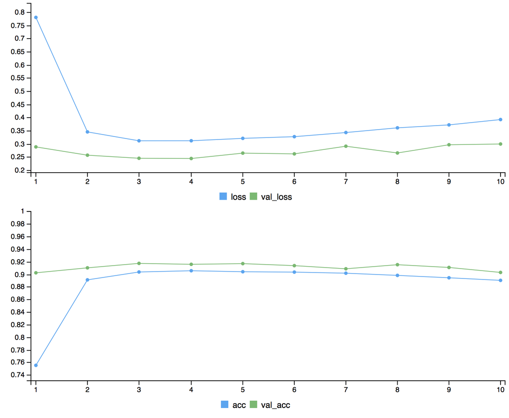

# Problem 3

Preparation

```r
library(ggplot2)
```

In the first part, MAD function is used to observe the model performance with functions from book CASL.

```r
# Create list of weights to describe a dense neural network.
#
# Args:
#     sizes: A vector giving the size of each layer, including
#
#
# Returns:
#     A list containing initialized weights and biases.
casl_nn_make_weights <- function(sizes){
  L <- length(sizes) - 1L
  weights <- vector("list", L)
  for (j in seq_len(L)){
    w <- matrix(rnorm(sizes[j] * sizes[j + 1L]),
            ncol = sizes[j],
            nrow = sizes[j + 1L])
    weights[[j]] <- list(w=w,
                     b=rnorm(sizes[j + 1L]))
  }
  weights
}
weight <- casl_nn_make_weights(c(1, 25, 1))
```

```r
# Apply a rectified linear unit (ReLU) to a vector/matrix.
#
# Args:
#     v: A numeric vector or matrix.
#
# Returns:
#     The original input with negative values truncated to zero.
casl_util_ReLU <- function(v){
v[v < 0] <- 0
v }
```

```r
# Apply derivative of the rectified linear unit (ReLU).
#
# Args:
#     v: A numeric vector or matrix.
#
# Returns:
#     Sets positive values to 1 and negative values to zero.
casl_util_ReLU_p <- function(v){
  p <- v * 0
  p[v > 0] <- 1
  p
}
```

```r
# Derivative of the mean absolute deviance (MAD) function.
#
# Args:
#     y: A numeric vector of responses.
#     a: A numeric vector of predicted responses.
#
# Returns:
#     Returned current derivative the MAD function.
# To avoid some unexplainable error that may occur, I didn't change the
# name of the function here
casl_util_mse_p <- function(y, a){
  temp <- c()
  for(i in 1:length(a)){
    if( y[i] <= a[i])
      temp[i] <- 1
    else
      temp[i] <- -1
  }
  temp
}
```

```r
# Apply forward propagation to a set of NN weights and biases.
#
# Args:
#     x: A numeric vector representing one row of the input.
#     weights: A list created by casl_nn_make_weights.
#     sigma: The activation function.
#
# Returns:
#     A list containing the new weighted responses (z) and
#     activations (a).
casl_nn_forward_prop <- function(x, weights, sigma){
  L <- length(weights)
  z <- vector("list", L)
  a <- vector("list", L)
  for (j in seq_len(L)){
  a_j1 <- if(j == 1) x else a[[j - 1L]]
  z[[j]] <- weights[[j]]$w %*% a_j1 + weights[[j]]$b
  a[[j]] <- if (j != L) sigma(z[[j]]) else z[[j]]
  }
  list(z=z, a=a)
}
```

```r
# Apply backward propagation algorithm.
#
# Args:
#     x: A numeric vector representing one row of the input.
#     y: A numeric vector representing one row of the response.
#     weights: A list created by casl_nn_make_weights.
#     f_obj: Output of the function casl_nn_forward_prop.
#     sigma_p: Derivative of the activation function.
#     f_p: Derivative of the loss function.
#
# Returns:
#     A list containing the new weighted responses (z) and
#     activations (a).
casl_nn_backward_prop <- function(x, y, weights, f_obj, sigma_p, f_p){
  z <- f_obj$z
  a <- f_obj$a
  L <- length(weights)
  grad_z <- vector("list", L)
  grad_w <- vector("list", L)
  for (j in rev(seq_len(L))){
    if (j == L) {
      grad_z[[j]] <- f_p(y, a[[j]])
      } else {
        grad_z[[j]] <- (t(weights[[j + 1]]$w) %*% grad_z[[j + 1]]) * sigma_p(z[[j]])
        }
    a_j1 <- if(j == 1) x else a[[j - 1L]]
    grad_w[[j]] <- grad_z[[j]] %*% t(a_j1)
    }
  list(grad_z=grad_z, grad_w=grad_w)
}
```

```r
# Apply stochastic gradient descent (SGD) to estimate NN.
#
# Args:
#     X: A numeric data matrix.
#     y: A numeric vector of responses.
#     sizes: A numeric vector giving the sizes of layers in
#            the neural network.
#     epochs: Integer number of epochs to computer.
#     eta: Positive numeric learning rate.
#     weights: Optional list of starting weights.
#
# Returns:
#     A list containing the trained weights for the network.
casl_nn_sgd <- function(X, y, sizes, epochs, eta, weights=NULL){
  if (is.null(weights)){
    weights <- casl_nn_make_weights(sizes)
  }
  ## for every individual, update the weights; repeat the procedure over all individuals.
  for (epoch in seq_len(epochs)){
    for (i in seq_len(nrow(X))){
      f_obj <- casl_nn_forward_prop(X[i,], weights, casl_util_ReLU)
      b_obj <- casl_nn_backward_prop(X[i,], y[i,], weights,
                                     f_obj, casl_util_ReLU_p, casl_util_mse_p)
      for (j in seq_along(weights)){
        weights[[j]]$b <- weights[[j]]$b -eta * b_obj$grad_z[[j]]
        weights[[j]]$w <- weights[[j]]$w -eta * b_obj$grad_w[[j]]
      }
    }
  }
  weights
}
```

```r
# Predict values from a training neural network.
#
# Args:
#     weights: List of weights describing the neural network.
#     X_test: A numeric data matrix for the predictions.
#
# Returns:
#     A matrix of predicted values.
casl_nn_predict <- function(weights, X_test){
  p <- length(weights[[length(weights)]]$b)
  y_hat <- matrix(0, ncol = p, nrow = nrow(X_test))
  for (i in seq_len(nrow(X_test))){
    a <- casl_nn_forward_prop(X_test[i,], weights, casl_util_ReLU)$a
    y_hat[i, ] <- a[[length(a)]]
    }
  y_hat
}
```

Simulation

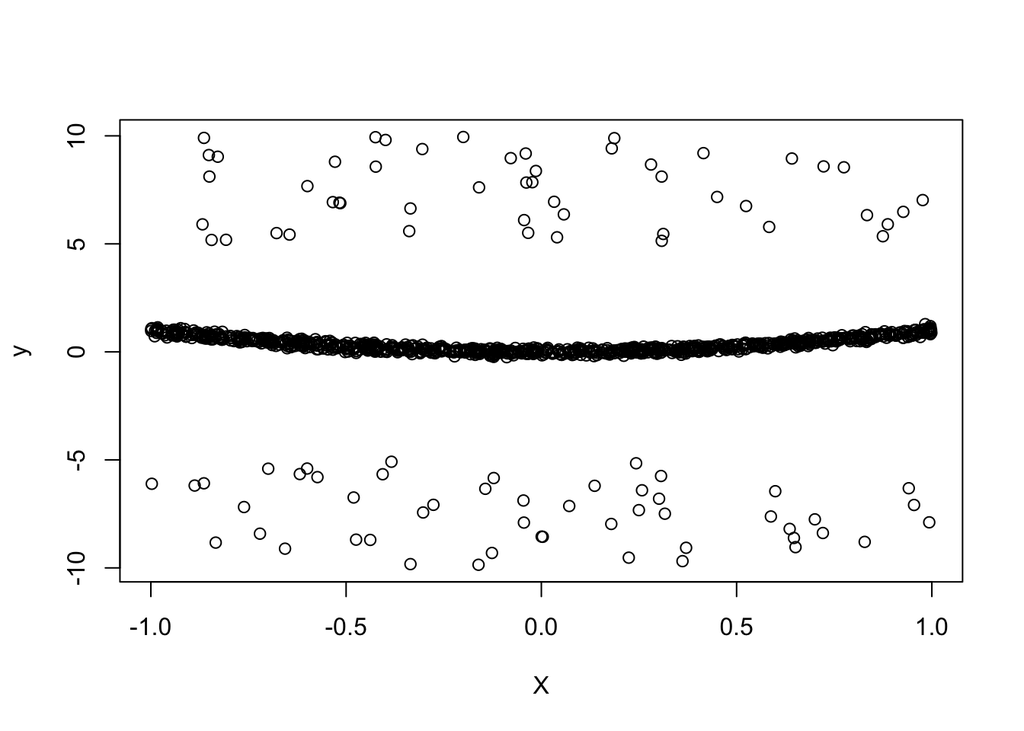

```r
set.seed(1215)
X <- matrix(runif(1000, min=-1, max=1), ncol=1)
s <- sample(1:1000, 100)
y<-rep(0,1000)
y[-s] <- X[-s,1,drop = FALSE]^2 + rnorm(900, sd = 0.1)
y[sort(s)] <- c(runif(50,-10,-5),runif(50,5,10))
y<-as.matrix(y)
plot(X,y)
```

Results for MAD

```r
weights <- casl_nn_sgd(X, y, sizes = c(1, 25, 1), epochs=15, eta=0.01)
y_pred_mad <- casl_nn_predict(weights, X)
```

```r
mse<-function(y_pred,y){
  mean((y_pred-y)^2)
}
mse(y_pred_mad,y)
```

```
## [1] 5.790305
```

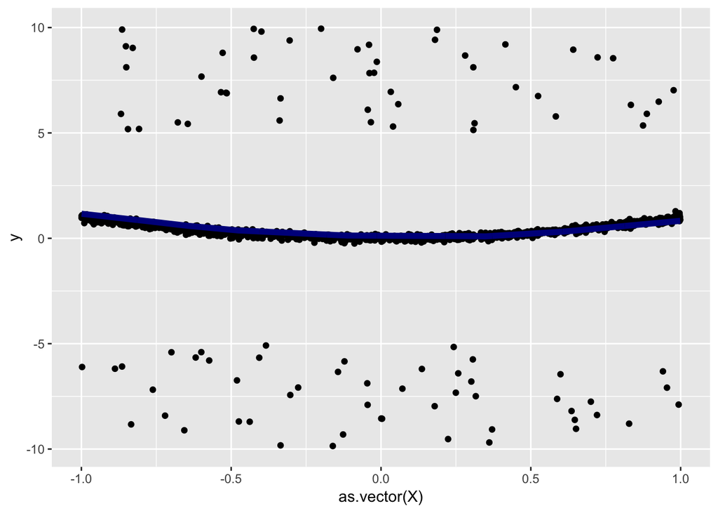

```r
data_mad<-cbind(y,y_pred_mad,X)
plot_mad<-ggplot(as.data.frame(data_mad))+geom_point(aes(x=as.vector(X),y=y))
plot_mad+geom_line(aes(x=as.vector(X),y=y_pred_mad),colour = "darkblue",size =2)
```

In the first part, MSE function is used to observe the model performance with functions from book CASL.

```r
# Create list of weights to describe a dense neural network.
#
# Args:
#     sizes: A vector giving the size of each layer, including
#
#
# Returns:
#     A list containing initialized weights and biases.
casl_nn_make_weights <- function(sizes){
  L <- length(sizes) - 1L
  weights <- vector("list", L)
  for (j in seq_len(L)){
    w <- matrix(rnorm(sizes[j] * sizes[j + 1L]),
            ncol = sizes[j],
            nrow = sizes[j + 1L])
    weights[[j]] <- list(w=w,
                     b=rnorm(sizes[j + 1L]))
  }
  weights
}
weight <- casl_nn_make_weights(c(1, 25, 1))
```

```r
# Apply a rectified linear unit (ReLU) to a vector/matrix.
#
# Args:
#     v: A numeric vector or matrix.
#
# Returns:
#     The original input with negative values truncated to zero.
casl_util_ReLU <- function(v){
v[v < 0] <- 0
v }
```

```r
# Apply derivative of the rectified linear unit (ReLU).
#
# Args:
#     v: A numeric vector or matrix.
#
# Returns:
#     Sets positive values to 1 and negative values to zero.
casl_util_ReLU_p <- function(v){
  p <- v * 0
  p[v > 0] <- 1
  p
}
```

```r
# Derivative of the mean absolute deviance (MAD) function.
#
# Args:
#     y: A numeric vector of responses.
#     a: A numeric vector of predicted responses.
#
# Returns:
#     Returned current derivative the MAD function.
casl_util_mse_p <- function(y, a){
  2*(a-y)
}
```

```r
# Apply forward propagation to a set of NN weights and biases.
#
# Args:
#     x: A numeric vector representing one row of the input.
#     weights: A list created by casl_nn_make_weights.
#     sigma: The activation function.
#
# Returns:
#     A list containing the new weighted responses (z) and
#     activations (a).
casl_nn_forward_prop <- function(x, weights, sigma){
  L <- length(weights)
  z <- vector("list", L)
  a <- vector("list", L)
  for (j in seq_len(L)){
  a_j1 <- if(j == 1) x else a[[j - 1L]]
  z[[j]] <- weights[[j]]$w %*% a_j1 + weights[[j]]$b
  a[[j]] <- if (j != L) sigma(z[[j]]) else z[[j]]
  }
  list(z=z, a=a)
}
```

```r
# Apply backward propagation algorithm.
#
# Args:
#     x: A numeric vector representing one row of the input.
#     y: A numeric vector representing one row of the response.
#     weights: A list created by casl_nn_make_weights.
#     f_obj: Output of the function casl_nn_forward_prop.
#     sigma_p: Derivative of the activation function.
#     f_p: Derivative of the loss function.
#
# Returns:
#     A list containing the new weighted responses (z) and
#     activations (a).
casl_nn_backward_prop <- function(x, y, weights, f_obj, sigma_p, f_p){
  z <- f_obj$z
  a <- f_obj$a
  L <- length(weights)
  grad_z <- vector("list", L)
  grad_w <- vector("list", L)
  for (j in rev(seq_len(L))){
    if (j == L) {
      grad_z[[j]] <- f_p(y, a[[j]])
      } else {
        grad_z[[j]] <- (t(weights[[j + 1]]$w) %*% grad_z[[j + 1]]) * sigma_p(z[[j]])
        }
    a_j1 <- if(j == 1) x else a[[j - 1L]]
    grad_w[[j]] <- grad_z[[j]] %*% t(a_j1)
    }
  list(grad_z=grad_z, grad_w=grad_w)
}
```

```r
# Apply stochastic gradient descent (SGD) to estimate NN.
#
# Args:
#     X: A numeric data matrix.
#     y: A numeric vector of responses.
#     sizes: A numeric vector giving the sizes of layers in
#            the neural network.
#     epochs: Integer number of epochs to computer.
#     eta: Positive numeric learning rate.
#     weights: Optional list of starting weights.
#
# Returns:
#     A list containing the trained weights for the network.
casl_nn_sgd <- function(X, y, sizes, epochs, eta, weights=NULL){
  if (is.null(weights)){
    weights <- casl_nn_make_weights(sizes)
  }
  ## for every individual, update the weights; repeat the procedure over all individuals.
  for (epoch in seq_len(epochs)){
    for (i in seq_len(nrow(X))){
      f_obj <- casl_nn_forward_prop(X[i,], weights, casl_util_ReLU)
      b_obj <- casl_nn_backward_prop(X[i,], y[i,], weights,
                                     f_obj, casl_util_ReLU_p, casl_util_mse_p)
      for (j in seq_along(weights)){
        weights[[j]]$b <- weights[[j]]$b -eta * b_obj$grad_z[[j]]
        weights[[j]]$w <- weights[[j]]$w -eta * b_obj$grad_w[[j]]
      }
    }
  }
  weights
}
```

```r
# Predict values from a training neural network.
#
# Args:
#     weights: List of weights describing the neural network.
#     X_test: A numeric data matrix for the predictions.
#
# Returns:
#     A matrix of predicted values.
casl_nn_predict <- function(weights, X_test){
  p <- length(weights[[length(weights)]]$b)
  y_hat <- matrix(0, ncol = p, nrow = nrow(X_test))
  for (i in seq_len(nrow(X_test))){
    a <- casl_nn_forward_prop(X_test[i,], weights, casl_util_ReLU)$a
    y_hat[i, ] <- a[[length(a)]]
    }
  y_hat
}
```

Results for MSE

```r
weights <- casl_nn_sgd(X, y, sizes = c(1, 25, 1), epochs=15, eta=0.01)
y_pred_mse <- casl_nn_predict(weights, X)
```

```r
mse<-function(y_pred,y){
  mean((y_pred-y)^2)
}
mse(y_pred_mse,y)
```

```
## [1] 6.73363
```

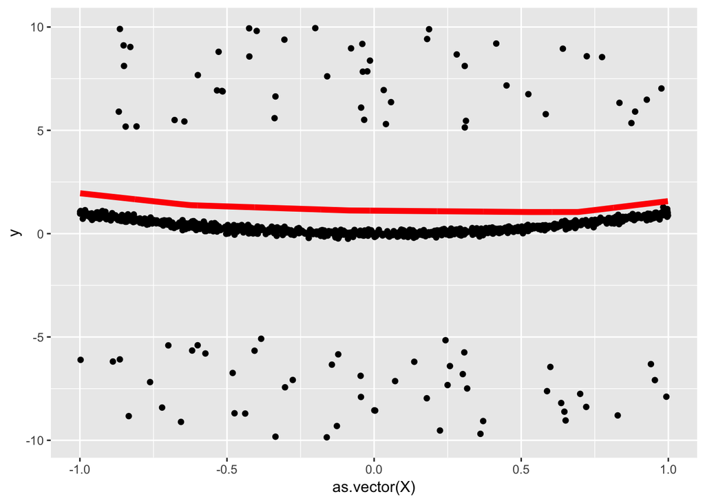

```r
data_mse<-cbind(y,y_pred_mse,X)
plot_mse<-ggplot(as.data.frame(data_mse))+geom_point(aes(x=as.vector(X),y=y))
plot_mse+geom_line(aes(x=as.vector(X),y=y_pred_mse),colour = "red",size =2)
```

Comparison

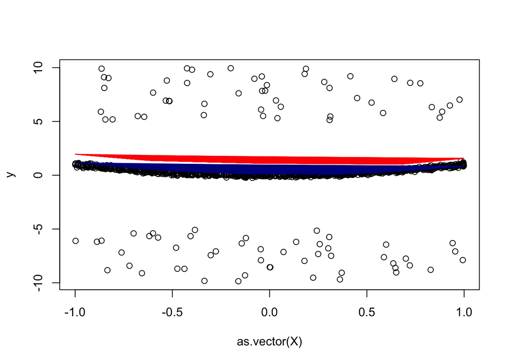

```r
plot(as.vector(X), y, col="black" )
lines(as.vector(X), y_pred_mad, col="darkblue")
lines(as.vector(X),y_pred_mse, col="red")
```

From the plot, we can see that MAD function is more robust compared with MSE function when outliers exist.